# EDA Analysis Workbook

Sympathetic nervous system activity as measured through skin conductance as an index of infant responsiveness to arousal in the Face-to-face Still-face paradigm

Louis Klein

### Initialise document and load some packages

### Prepare data for modelling

```r
# make list of dead channels
dead_channels <- output %>%
  mutate(phase = fct_relevel(phase,"play","sf","reunion")) %>%
  group_by(participant) %>%
  summarise(avg_conduc = mean(conduc)) %>%
  filter(avg_conduc < 1 | avg_conduc > 120) %>%
  distinct(participant)
```

#### UPDATED 28-10-20: Inverting time-series by phase and centering final sample on 0

```r
glimpse(sf_phase)
```

```
Rows: 909
Columns: 3
Groups: participant, phase [909]
$ participant <fct> 3115, 3115, 3115, 3125, 3125, 3125, 3128, 3128, 3128, 3134, 3134, 3134, 3143, 3143, 3143, 3…
$ phase       <fct> play, sf, reunion, play, sf, reunion, play, sf, reunion, play, sf, reunion, play, sf, reuni…
$ data        <list> [<tbl_df[1870 x 11]>, <tbl_df[3456 x 11]>, <tbl_df[892 x 11]>, <tbl_df[2400 x 11]>, <tbl_d…
```

### Model conductance for each participant by phase with resistance and accel_xyz as covariates

### Extract the model for each participant by phase

```r
glimpse(sf_px)
```

```
Rows: 909
Columns: 8
Groups: participant, phase [909]
$ id          <fct> 1, 2, 3, 4, 5, 6, 7, 8, 9, 10, 11, 12, 13, 14, 15, 16, 17, 18, 19, 20, 21, 22, 23, 24, 25, …
$ participant <fct> 3115, 3115, 3115, 3125, 3125, 3125, 3128, 3128, 3128, 3134, 3134, 3134, 3143, 3143, 3143, 3…
$ phase       <fct> play, sf, reunion, play, sf, reunion, play, sf, reunion, play, sf, reunion, play, sf, reuni…
$ rsq         <dbl> 0.50327402, 0.64524279, 0.89820582, 0.92333142, 0.97245447, 0.98188630, 0.97812588, 0.99234…
$ intercept   <dbl> 31.6192225, 31.1828560, 25.0140960, 59.3018506, 63.6439644, 67.1201623, 39.1686280, 45.9421…
$ slope       <dbl> 1.192065e-02, 6.007435e-04, 1.273463e-02, 1.735436e-02, -1.640232e-02, 7.636574e-03, 1.6539…
$ resist      <dbl> -1.333648e-04, -2.226587e-01, -1.375338e-01, -4.653077e-01, -7.434886e-01, -1.019347e+00, -…
$ accel_xyz   <dbl> -1.5348880199, 0.0046802277, 0.0197610030, -0.5148904233, -0.3642863326, -0.0295423663, -0.…
```

### Let’s interpret the models descriptively

- might want to explore the Anderson-Darling test `nortest::ad.test()`

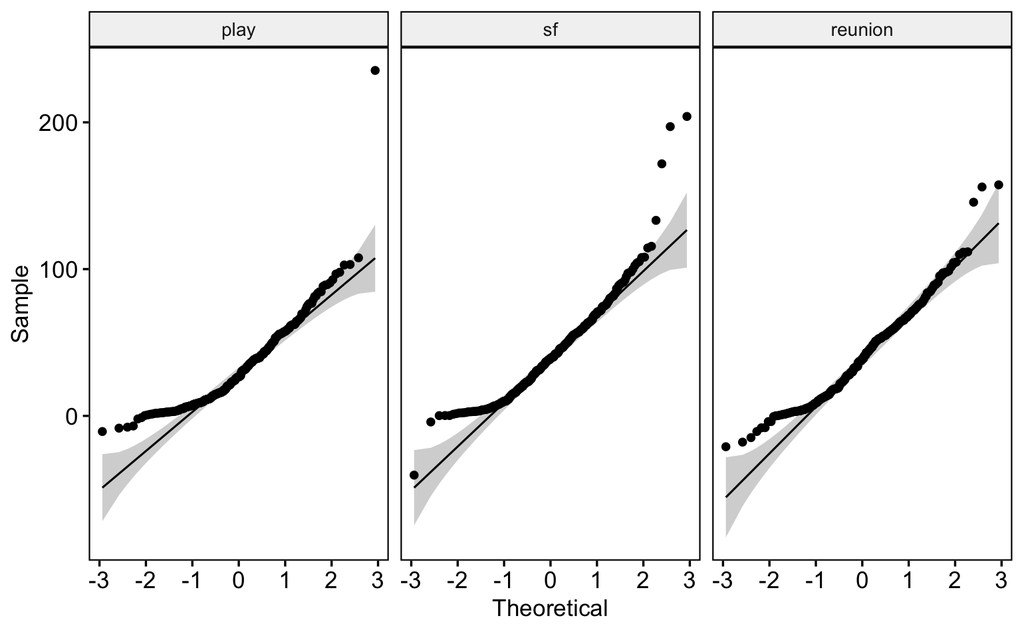

### Visualising the data

```r
### Build separate plots -------------------------------------------------------

# linear models of conductance by play phase
play_pl <- sf_px %>%
  ungroup() %>%
  filter(phase == "play") %>% {
  ggplot(.) + theme_bw() + xlim(0,4) + ylim(0, 200) +
  geom_abline(intercept = .$intercept, slope = .$slope, alpha = .$rsq/2.5) +
  geom_hline(yintercept = mean(.$intercept), colour = "red", size = 1) +
  geom_hline(yintercept = median(.$intercept), colour = "blue", size = 1) +
  labs(x = "Free play", y = "Skin conductance (μS)")
  }

# linear models of conductance by play phase
sf_pl <- sf_px %>%
  ungroup() %>%
  filter(phase == "sf") %>% {
  ggplot(.) + theme_bw() + xlim(0,1.5) + ylim(0, 200) +
  geom_abline(intercept = .$intercept, slope = .$slope, alpha = .$rsq/2.5) +
  geom_hline(yintercept = mean(.$intercept), colour = "red", size = 1) +
  geom_hline(yintercept = median(.$intercept), colour = "blue", size = 1) +
  labs(x = "Still-face")
  }

# linear models of conductance by play phase
reunion_pl <- sf_px %>%
  ungroup() %>%
  filter(phase == "reunion") %>% {
  ggplot(.) + theme_bw() + xlim(0,2) + ylim(0, 200) +
  geom_abline(intercept = .$intercept, slope = .$slope, alpha = .$rsq/2.5) +
  geom_hline(yintercept = mean(.$intercept), colour = "red", size = 1) +
  geom_hline(yintercept = median(.$intercept), colour = "blue", size = 1) +
  labs(x = "Reunion")
  }

### Splice them together -------------------------------------------------------

library(grid)
library(egg)
# Visualise differences by phase
sf_figure <- ggarrange(
  play_pl,
  sf_pl +
    theme(axis.text.y = element_blank(),
                     axis.ticks.y = element_blank(),
                     axis.title.y = element_blank()),
  reunion_pl +
    theme(axis.text.y = element_blank(),
                     axis.ticks.y = element_blank(),
                     axis.title.y = element_blank()),
  widths = c(4,1.5,2),
  nrow = 1)

annotate_figure(sf_figure,
  top = textGrob(
    "Visualisation of linear models by participant by phase",
    hjust = 1.72, x = 1
  ),
  bottom = textGrob(
    "CBRC: Louis Klein, 15-07-20",
    gp = gpar(fontface = 3, fontsize = 9),
    hjust = 1.07, x = 1 # these right-justify the footnote
  )
)
```

### Hypothesis testing

```r
library(rstatix)
# run mixed-ANOVA with repeated measures
sf_px %>%
  ungroup() %>%
  filter(intercept > 0, intercept < 200) %>%
  anova_test(dv = intercept,
             wid = participant,
             between = phase) %>%
  get_anova_table() %>%
  adjust_pvalue(method = "bonferroni")
```

```r
artefact_filepaths <- list.files("output/artefact-detection", pattern = "*.csv",full.names = TRUE) %>%
  as_tibble() %>%
  rename(filepath_in = "value") %>%
  mutate(channels = substring(filepath_in,27,35))

peak_filepaths <- list.files("output/peak-detection", pattern = "*.csv",full.names = TRUE) %>%
  as_tibble() %>%
  rename(filepath_in = "value") %>%
  mutate(channels = substring(filepath_in,23,31))

# prepare output dataframe
combined <- peak_filepaths[[2]] %>%
  as_tibble() %>%
  rename(channels = value)
```

```r
# helper function to produce epochs in peak data
epochr <- function(value,base) {
  base*floor(value/base)
}

phase_ts <- output_prep %>%
  select(1:5) %>%
  group_by(participant,device,phase) %>%
  filter(phase_t == 0) %>%
  mutate(
    timestamp = as.numeric(as.POSIXct(timestamp)),
    epoch_start = epochr(timestamp,5),
    channels = paste0(participant,"_",device)
    ) %>%
  select(1:2,4:3,6:7) %>%
  nest(phases = c(1:5)) %>%
  semi_join(combined,by="channels") %>%
  left_join(artefact_filepaths,by="channels") %>%
  left_join(peak_filepaths,by="channels") %>%
  mutate(analyses = NA)
```

```r
phase_ts <- phase_ts %>%
  unnest(c(analyses)) %>%
  mutate(master = NA)

for (i in seq_along(phase_ts[[1]])) {

  temp_a <- phase_ts[[1]][i]

  temp_b <- phase_ts %>%
    filter(channels == temp_a) %>%
    unnest(phases) %>%
    select(1:6)

  # adding phase label to constrain end of experiment appropriately
  temp_d <- temp_b[3,] %>%
    mutate(phase = "terminated",
           timestamp = timestamp+240,
           epoch_start = epochr(timestamp,5))
  temp_e <- rbind(temp_b,temp_d)

  temp_c <- phase_ts %>%
  filter(channels == temp_a) %>%
  unnest(analyses) %>%
  select(1,5:16)

  phase_ts[[6]][[i]] <- full_join(temp_e,temp_c,by="epoch_start") %>%
    arrange(epoch_start) %>%
    fill(1:4) %>%
    select(2:4,8,6,9:18) %>%
    rename(peak = timestamp.y) %>%
    nest(clean = everything())
}

phase_ts <- phase_ts %>%
  unnest(c(master))
```

```r
# how many peak events have been detected per phase by participant by device?
phase_ts %>%
  select(clean) %>%
  unnest(clean) %>%
  group_by(participant,device,phase) %>%
  filter(phase!="terminated",!is.na(EDA),!is.na(participant)) %>%
  rstatix::reorder_levels("phase", order = c("play","sf","reunion")) %>%
  count(phase)

# what is the average number of peak events by phase?
phase_ts %>%
  select(clean) %>%
  unnest(clean) %>%
  group_by(participant,device,phase) %>%
  filter(phase!="terminated",!is.na(EDA),!is.na(participant)) %>%
  count(phase) %>%
  ungroup() %>%
  group_by(phase) %>%
  rstatix::reorder_levels("phase", order = c("play","sf","reunion")) %>%
  summarise(by_phase = mean(n))

# what is the proportion of peak events by phase?
phase_ts %>%
  select(clean) %>%
  unnest(clean) %>%
  group_by(participant,device,phase) %>%
  filter(phase!="terminated",!is.na(EDA),!is.na(participant)) %>%
  rstatix::reorder_levels("phase", order = c("play","sf","reunion")) %>%
  count(phase) %>%
  mutate(N = case_when(phase == "play" | phase == "reunion" ~ n/240*100,
                       phase == "sf" ~ n/90*100)) %>%
  ungroup() %>%
  group_by(phase) %>%
  summarise(by_phase = mean(N))

# which phase did children have the most artefacts in?
phase_ts %>%
  select(clean) %>%
  unnest(clean) %>%
  group_by(phase) %>%
  filter(phase != "terminated",!is.na(MulticlassLabels),!is.na(participant)) %>%
  rstatix::reorder_levels("phase", order = c("play","sf","reunion")) %>%
  select(1:3,7) %>%
  count(MulticlassLabels) %>%
  mutate(phase_total = sum(n),
         proportion = round(n/phase_total*100)) %>%
  select(-4)
```

- peak frequencies -> Shriya
- note on dependent variable
- brief notes for methods section
- add proportion of peaks by phase column
- single .csv file

```r
shriya <- phase_ts %>%
  select(clean) %>%
  unnest(clean) %>%
  group_by(participant,device,phase) %>%
  filter(phase!="terminated",!is.na(EDA),!is.na(participant)) %>%
  rstatix::reorder_levels("phase", order = c("play","sf","reunion")) %>%
  count(phase) %>%
  mutate(N = case_when(phase == "play" | phase == "reunion" ~ n/240*100,
                       phase == "sf" ~ n/90*100))

write_csv(shriya,file.path(getwd(),"REAL_peaks_28-10-20.csv"))
```

```r
shriya %>%
  ggplot(aes(phase,N,fill=device)) +
  geom_boxplot()
```

#### Revised data processing and simulation

```r
# 197 dead channels in total
dead_channels <- output %>%
  group_by(participant,device) %>%
  select(1:2,8) %>%
  mutate(avg_conduc = mean(conduc)) %>%
  filter(avg_conduc < 10 | avg_conduc > 60) %>%
  distinct(participant,device)

# 119 participants affected
dead_channels %>%
  ungroup() %>%
  select(participant) %>%
  distinct()

# exclude dead channels and collapse accelerometer columns
output_clean <- output %>%
  group_by(participant, device, phase) %>%
  # anti_join(dead_channels, by = "participant") %>%
  mutate(phase = fct_relevel(phase,"play","sf","reunion"),
         accel_xyz = abs(accel_x) + abs(accel_y) + abs(accel_z))

# 387 clean channels for 194 participants included
# 193 infants with 2 channels; 1 with 1 channel
output_clean %>%
  ungroup() %>%
  distinct(participant,device) %>%
  count(participant) %>%
  filter(n == 1)

# Ottmar Lippe: Curtain University

### Randomise devices ----------------------------------------------------------

sim <- function (data) {

  # simple multivariate linear modeling function
  phase_fx <- function (df) {lm(conduc ~ phase_t + accel_xyz, data = df)}

    # randomly assign participants by device
    rand <- data %>%
      ungroup() %>%
      select(participant, device) %>%
      group_by(participant, device) %>%
      unique()
    rand %<>% group_by(participant) %>% mutate(assign = sample(c(0,1), size = 1, replace = TRUE))
    rand <- rand[permute::shuffle(rand),]
    rand$dup <- duplicated(rand[,c(1,3)])
    rand <- rand[-which(rand$dup),]
    rand %<>% select(1:2) %>% arrange(participant)

    # merge rand with `frog_lm` and delete rejected channels
    temp <- data %>%
      anti_join(rand, by = c("participant", "device")) %>%
      ungroup() %>% group_by(participant,device,phase) %>%
      nest() %>%
      mutate(
        mod = map(data, phase_fx),
        tidy = mod %>% map(broom::tidy),
        intercept = tidy %>% map("estimate") %>% map(1),# this 'plucks' the intercept value
        se = tidy %>% map("estimate") %>% map(2)
      ) %>%
      select(participant,device,phase,intercept,se)

  return(temp)
}
```

```r
channels_simulated <- replicate(10000,sim(output_prep),simplify = FALSE)
```

```r
channels_simulated_clean <- channels_simulated %>%
  imap(~mutate(.x, rep = .y)) %>%
  map_df(as_tibble) %>%
  group_by(participant,device,phase) %>%
  mutate(
    rep = as.factor(rep),
    intercept = as.numeric(intercept),
    se = as.numeric(se)
  ) %>%
  select(6,1:5) %>%
  arrange(participant)

# optionally remove outliers
outliers <- sf_px %>%
  ungroup() %>%
  group_by(phase) %>%
  rstatix::identify_outliers(intercept) %>%
# filter(is.extreme == TRUE) %>% # titrate outlier extremity
  select(participant, phase)

channels_sim_outliers <- channels_simulated_clean %>%
  ungroup() %>%
  anti_join(outliers,
            by=c("participant","phase"))

# how many participants were removed?
(dim(channels_simulated_clean)-dim(channels_sim_outliers))/10000

# what is the difference in intercept average across replications by phase?
channels_simulated_clean %>%
  ungroup() %>%
  filter(intercept > 0, intercept < 200) %>%
  group_by(device,phase) %>%
  summarise(intercept_average = mean(intercept),
            se_average = mean(se))

# does it matter that the phases are different lengths?
channels_simulated_clean %>%
  ungroup() %>%
  filter(intercept > 0, intercept < 200) %>%
  group_by(device,phase) %>%
  summarise(intercept_average = mean(intercept),
            se_average = mean(se)) %>%
  mutate_at(vars(intercept_average,se_average),~case_when(phase == "play" ~ .,
                                                          phase == "sf" ~ ./(190/240),
                                                          phase == "reunion" ~ .))
```

fix this

```r
# what are the between-phase differences by device using the simulation data
channels_simulated_clean %>%
  pivot_wider(names_from = phase,values_from = c(intercept,se)) %>%
  group_by(participant,device) %>%
  summarise(play_sf = intercept_sf-intercept_play,
            sf_reunion = intercept_reunion-intercept_sf) %>%
  ungroup() %>% group_by(device) %>%
  summarise(play_sf = mean(play_sf),
            sf_reunion = mean(sf_reunion))
```

```r
# what is the between-device difference in average intercept by participant by phase?
channels_simulated_clean %>%
  ungroup() %>%
  select(2:6) %>%
  filter(intercept > 0, intercept < 200) %>%
  group_by(participant,device,phase) %>%
  summarise(intercept_average = mean(intercept),
            se_average = mean(se)) %>%
  pivot_wider(names_from = device,
              values_from = c(intercept_average,se_average)) %>%
  mutate(intercept_difference = abs((intercept_average_CD1C-intercept_average_CD2B)),
         se_difference = abs((se_average_CD1C-se_average_CD2B))) %>%
  select(participant,phase,intercept_difference,se_difference)

# what is overall between-device difference?
channels_simulated_clean %>%
  ungroup() %>%
  select(2:6) %>%
  filter(intercept > 0, intercept < 200) %>%
  group_by(participant,device,phase) %>%
  summarise(intercept_average = mean(intercept),
            se_average = mean(se)) %>%
  pivot_wider(names_from = device,
              values_from = c(intercept_average,se_average)) %>%
  mutate(intercept_difference = (intercept_average_CD1C-intercept_average_CD2B),
         se_difference = (se_average_CD1C-se_average_CD2B)) %>%
  select(participant,phase,intercept_difference,se_difference) %>%
  ungroup() %>%
  drop_na(intercept_difference,se_difference) %>%
  group_by(phase) %>%
  summarise(overall_difference = mean(intercept_difference),
            overall_se = mean(se_difference))
```

```r
y_title <- expression(
  paste(
    "Mean skin conductance (",
    italic("μS"),
    ")"
  ))

play_sim <- channels_sim_outliers %>%
  ungroup() %>%
  group_by(rep,phase) %>%
  summarise(intercept = mean(intercept),
            se = mean(se)) %>%
  filter(phase == "play",intercept < 200) %>% {
  ggplot(.) + theme_bw() + xlim(0,4) + ylim(0, 60) +
  geom_abline(intercept = .$intercept, slope = 0, alpha = .006) +
  geom_hline(yintercept = mean(.$intercept), colour = "red", size = 1) +
  labs(x = "Free play", y = y_title)
  }

sf_sim <- channels_sim_outliers %>%
  ungroup() %>%
  group_by(rep,phase) %>%
  summarise(intercept = mean(intercept),
            se = mean(se)) %>%
  filter(phase == "sf",intercept < 200) %>% {
  ggplot(.) + theme_bw() + xlim(0,1.5) + ylim(0, 60) +
  geom_abline(intercept = .$intercept, slope = 0, alpha = .006) +
  geom_hline(yintercept = mean(.$intercept), colour = "red", size = 1) +
  labs(x = "Still-face")
  }

reunion_sim <- channels_sim_outliers %>%
  ungroup() %>%
  group_by(rep,phase) %>%
  summarise(intercept = mean(intercept),
            se = mean(se)) %>%
  filter(phase == "reunion",intercept < 200) %>% {
  ggplot(.) + theme_bw() + xlim(0,2) + ylim(0, 60) +
  geom_abline(intercept = .$intercept, slope = 0, alpha = .006) +
  geom_hline(yintercept = mean(.$intercept), colour = "red", size = 1) +
  labs(x = "Reunion")
  }

### Splice graphs together -----------------------------------------------------

library(ggpubr)
library(grid)
library(egg)

sf_figure <- ggarrange(
  play_sim,
  sf_sim +
    theme(axis.text.y = element_blank(),
                     axis.ticks.y = element_blank(),
                     axis.title.y = element_blank()),
  reunion_sim +
    theme(axis.text.y = element_blank(),
                     axis.ticks.y = element_blank(),
                     axis.title.y = element_blank()),
  widths = c(4,1.5,2),
  nrow = 1)

main_title <- expression(
  paste(
    "Simulation of mean conductance intercepts by participant by phase (",
    italic("n"),
    "=10000)"
  ))

annotate_figure(sf_figure,
  top = textGrob(
    main_title,
    hjust = 1.3, x = 1.09
  ),
  bottom = textGrob(
    "CBRC: Louis Klein, 29-10-20",
    gp = gpar(fontface = 3, fontsize = 9),
    hjust = 1.07, x = 1
  )
)
```

```r
load("~/Dropbox/r-projects/EARLY-CBRC/workspace_14-07-20.RData")

exclusions %>%
  mutate(participant = substr(datafile,1,4),
         channel = substr(datafile,23,26)) %>%
  mutate_at(vars(participant,channel),~as.factor(.)) %>%
  count(issue) %>%
  mutate(N = round(n/sum(n)*100))

# there are 2 participants with only 1 channel affected out of 34
exclusions %>%
  mutate(participant = substr(datafile,1,4),
         channel = substr(datafile,23,26)) %>%
  mutate_at(vars(participant,channel),~as.factor(.)) %>%
  distinct(participant,channel) %>%
  count(participant) %>%
  count(n)
```

separate intercept for each phase, then the Value column is added to that